# Activity monitoring

M-sil

11 avril 2017

1. Loading and preprocessing the data

It will read the csv file “activity” stored in the working directory then convert the dates factor into a date format.

```r
path<-getwd()
data_activity<-read.csv(file.path(path,"activity.csv"))
data_activity$date<-as.Date(data_activity$date, format = "%Y-%m-%d")
```

2. Histogram of the total number of steps taken each day

First we calculate the total number of steps taken each day then we make a histogram of the frequency.

```r
total_steps<-aggregate(steps~date,data=data_activity,sum)
```

Here is the histogram of total step per day:

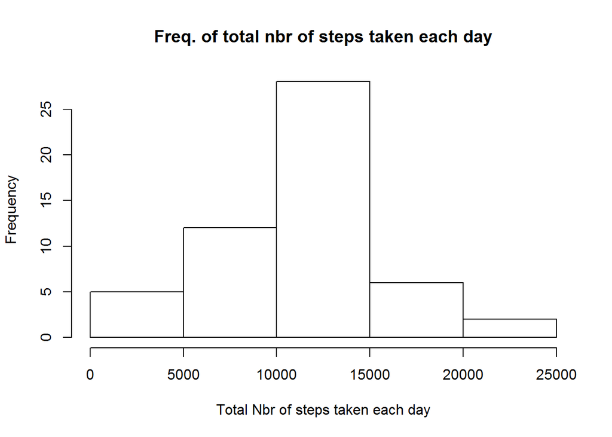

```r
hist(total_steps$steps,xlab="Total Nbr of steps taken each day",main="Freq. of total nbr of steps taken each day")
```

3. Mean and median number of steps taken each day

```r
total_steps_mean<-mean(total_steps$steps)
total_steps_med<-median(total_steps$steps)
```

4. Time series plot of the average number of steps taken

First, build the data frame averaging the number of steps per 5 min interval

```r
avg_steps_int<-aggregate(steps~interval, data_activity,mean)
```

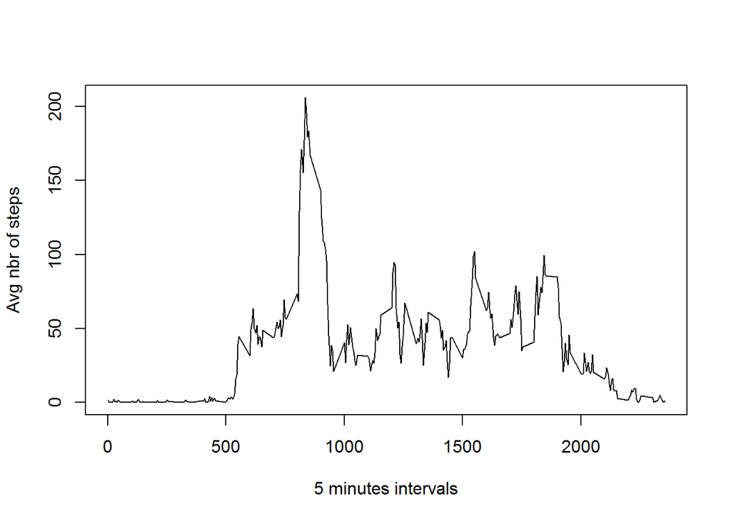

```r
plot(avg_steps_int$interval,avg_steps_int$steps, type = "l", xlab = "5 minutes intervals", ylab="Avg nbr of steps")
```

5. The 5-minute interval that, on average, contains the maximum number of steps

```r
max<-subset(avg_steps_int, steps == max(steps))
max$interval
```

```
## [1] 835
```

The 5 minutes interval that contains the maximum number of steps is 835

6. Code to describe and show a strategy for imputing missing data

First we calculate the total number of missing values:

```r
nb_na<-sum(is.na(data_activity$steps))
```

Then we replace all the missing values with the mean for that specific 5 minutes interval in a new data set called: new_data_activity

```r
new_data_activity<-data_activity
for(i in 1:nrow(new_data_activity)){
  if (is.na(new_data_activity$steps[i])){
  r <- avg_steps_int$steps[avg_steps_int$interval==new_data_activity$interval[i]]
  new_data_activity$steps[i]<-r
  }
}
```

7. Histogram of the total number of steps taken each day after missing values are imputed

First, we calculate total number of steps per day

```r
new_total_steps<-aggregate(steps~date,data=new_data_activity,sum)
```

Then, make the histogram of total step per day

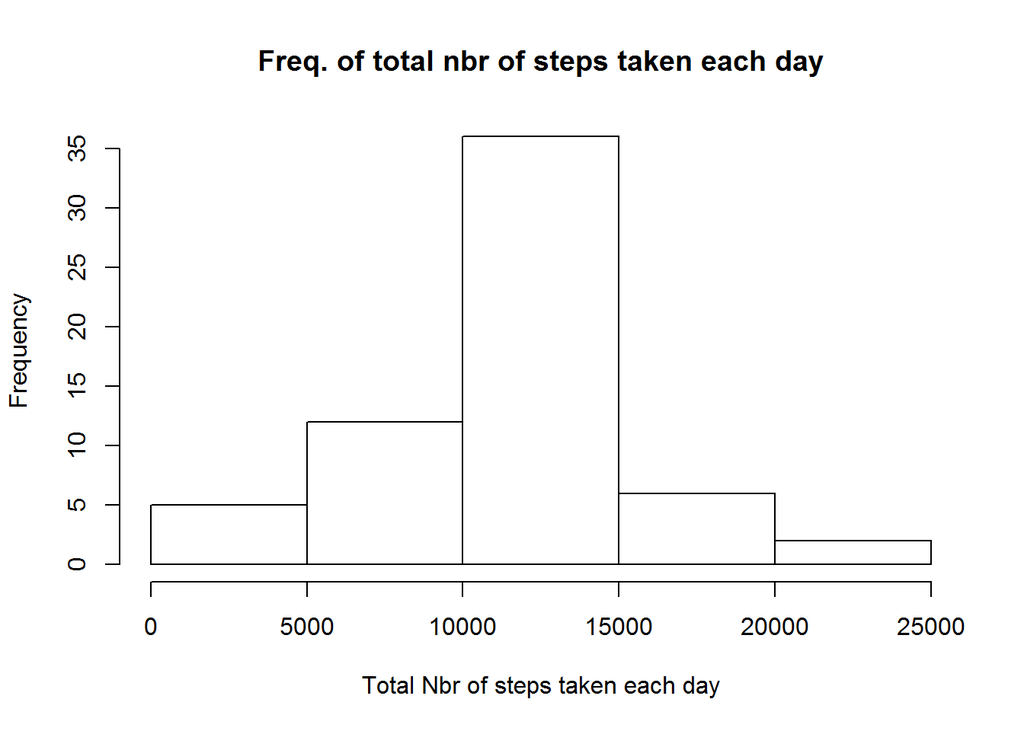

```r
hist(new_total_steps$steps,xlab="Total Nbr of steps taken each day",main="Freq. of total nbr of steps taken each day")
```

We also calculate the mean and the median of this new data set

```r
new_mean<-mean(new_total_steps$steps)
new_med<-median(new_total_steps$steps)
```

We can see that in this case the mean and the median are equal.

8. Panel plot comparing the average number of steps taken per 5-minute interval across weekdays and weekends

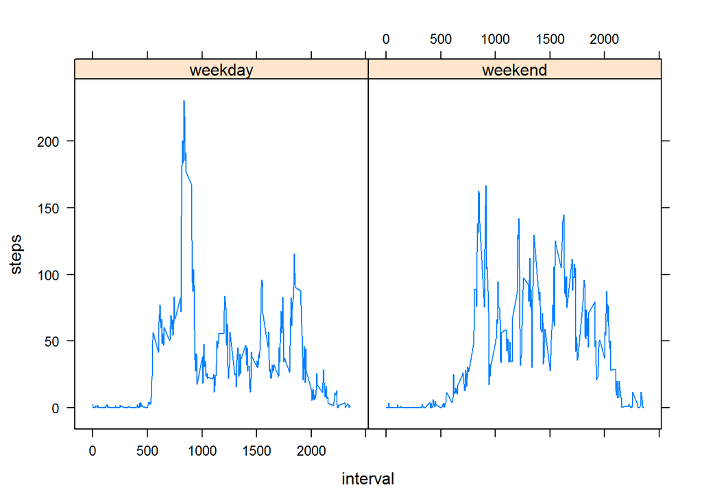

```r
#create a new variable indicating whether the day is a weekday or a weekend
for(i in 1:nrow(new_data_activity)){
  if (weekdays(new_data_activity$date[i]) == "samedi"|weekdays(new_data_activity$date[i]) == "dimanche"){
  new_data_activity$day[i]<-"weekend"
  }
  else {
    new_data_activity$day[i]<-"weekday"
  }
}
#Create a subset of only the "weekday" data then average the total nbr of steps per 5 min intervals
weekday<-subset(new_data_activity,day=="weekday")
avg_wd<-aggregate(steps~interval,data=weekday,mean)
avg_wd$day<-"weekday"
#Create a subset of only the "weekend" data then average the total nbr of steps per 5 min intervals
weekend<-subset(new_data_activity,day=="weekend")
avg_we<-aggregate(steps~interval,data=weekend,mean)
avg_we$day<-"weekend"
#Merge the two data frames
avg_tot<-rbind(avg_wd,avg_we)
#Make the time series in two different panels
library(lattice)
xyplot(steps ~ interval|day, avg_tot, t='l')
```